# Indego Bike Share Prediction

Michael Clifford

November 16, 2023

```r
library(tidyverse)
library(sf)
library(lubridate)
library(tigris)
library(tidycensus)
library(viridis)
library(riem)
library(gridExtra)
library(knitr)
library(kableExtra)
library(RSocrata)
library(mapview)
library(FNN)
library(caret)
library(stargazer)

root.dir = "https://raw.githubusercontent.com/urbanSpatial/Public-Policy-Analytics-Landing/master/DATA/"
source("https://raw.githubusercontent.com/urbanSpatial/Public-Policy-Analytics-Landing/master/functions.r")

plotTheme <- theme(
  plot.title =element_text(size=12),
  plot.subtitle = element_text(size=8),
  plot.caption = element_text(size = 6),
  axis.text.x = element_text(size = 10, angle = 45, hjust = 1),
  axis.text.y = element_text(size = 10),
  axis.title.y = element_text(size = 10),
  # Set the entire chart region to blank
  panel.background=element_blank(),
  plot.background=element_blank(),
  #panel.border=element_rect(colour="#F0F0F0"),
  # Format the grid
  panel.grid.major=element_line(colour="#D0D0D0",size=.2),
  axis.ticks=element_blank())

mapTheme <- theme(plot.title =element_text(size=12),
                  plot.subtitle = element_text(size=8),
                  plot.caption = element_text(size = 6),
                  axis.line=element_blank(),
                  axis.text.x=element_blank(),
                  axis.text.y=element_blank(),
                  axis.ticks=element_blank(),
                  axis.title.x=element_blank(),
                  axis.title.y=element_blank(),
                  panel.background=element_blank(),
                  panel.border=element_blank(),
                  panel.grid.major=element_line(colour = 'transparent'),
                  panel.grid.minor=element_blank(),
                  legend.direction = "vertical",
                  legend.position = "right",
                  plot.margin = margin(1, 1, 1, 1, 'cm'),
                  legend.key.height = unit(1, "cm"), legend.key.width = unit(0.2, "cm"))
```

```r
palette5 <- c("#eff3ff","#bdd7e7","#6baed6","#3182bd","#08519c")
palette5_2 <- c("#08519c", "#3182bd", "#6baed6", "#bdd7e7", "#eff3ff")
palette4 <- c("#D2FBD4","#92BCAB","#527D82","#123F5A")
palette2 <- c("#6baed6","#08519c")
```

## 1. Introduction

This analysis will explore spatial and temporal trends in the usage of Philadelphia’s Indego bike share service. In this system, users pick up a bike at a station and drop it off at another near their destination. As capacity at each station is limited, Indego is faced with the challenge of “re-balancing” their stations. Problems arise if a station is empty and potential users cannot get a bicycle for themselves. On the flip side, stations can become full, meaning a user will be unable to drop off their bike at their destination, and will be forced to find a more out of the way station to deposit it at.

The goal of this analysis then is to understand the recurring trends in bike share usage and create a model that can predict the trip count at every Indego station at every hour of the day. With this information, Indego can predict which stations will become overburdened, and efficiently dispatch workers in trucks to move bikes from stations with high demand to those with low demand, preventing shortages at busy stations and overflow at stations with many drop-offs. Given the intensity of Philadelphia traffic and the complexity of loading and off-loading on city streets, we think a 2-hour time lag feature is appropriate for this analysis. We will also include a 24-hour lag, as bike station usage throughout the day is probably similar throughout the week.

## 2. Data Wrangling, Exploratory Analysis, and Feature Engineering

I will examine a 5 week sample of Indego ridership data for this analysis, from August 6 to September 9, 2023. This includes one major holiday, Labor Day, on September 4.

```r
dat <- read.csv("indego-trips-2023-q3-2.csv")

dat$timestamp <- mdy_hm(dat$start_time)

dat <- dat[dat$timestamp >= ymd_hms("2023-08-06T00:00:00Z") &
                      dat$timestamp <= ymd_hms("2023-09-10T00:00:00Z"), ]
```

To ease the computational process, all trip timestamps will be “binned” into 15 and 60 minute intervals.

```r
dat2 <- dat %>%
  mutate(interval60 = floor_date(ymd_hms(timestamp), unit = "hour"),
         interval15 = floor_date(ymd_hms(timestamp), unit = "15 mins"),
         week = week(interval60),
         dotw = wday(interval60, label=TRUE))
```

```r
census <-
  get_acs(geography = "tract",
          variables = c("B01003_001", "B19013_001",
                        "B02001_002", "B08013_001",
                        "B08012_001", "B08301_001",
                        "B08301_010", "B01002_001"),
          year = 2021,
          state = "PA",
          geometry = TRUE,
          county=c("Philadelphia"),
          output = "wide") %>%
  rename(Total_Pop =  B01003_001E,
         Med_Inc = B19013_001E,
         Med_Age = B01002_001E,
         White_Pop = B02001_002E,
         Travel_Time = B08013_001E,
         Num_Commuters = B08012_001E,
         Means_of_Transport = B08301_001E,
         Total_Public_Trans = B08301_010E) %>%
  dplyr::select(Total_Pop, Med_Inc, White_Pop, Travel_Time,
         Means_of_Transport, Total_Public_Trans,
         Med_Age,
         GEOID, geometry) %>%
  mutate(Percent_White = White_Pop / Total_Pop,
         Mean_Commute_Time = Travel_Time / Total_Public_Trans,
         Percent_Taking_Public_Trans = Total_Public_Trans / Means_of_Transport)
```

```r
tracts <-
  census %>%
  as.data.frame() %>%
  distinct(GEOID, .keep_all = TRUE) %>%
  dplyr::select(GEOID, geometry) %>%
  st_sf
```

```r
dat_census <- st_join(dat2 %>%
          filter(is.na(start_lon) == FALSE &
                   is.na(start_lat) == FALSE &
                   is.na(end_lat) == FALSE &
                   is.na(end_lon) == FALSE) %>%
          st_as_sf(., coords = c("start_lon", "start_lat"), crs = 4326),
        tracts %>%
          st_transform(crs=4326),
        join=st_intersects,
              left = TRUE) %>%
  rename(Origin.Tract = GEOID) %>%
  mutate(start_lon = unlist(map(geometry, 1)),
         start_lat = unlist(map(geometry, 2)))%>%
  as.data.frame() %>%
  select(-geometry)%>%
  st_as_sf(., coords = c("end_lon", "end_lat"), crs = 4326) %>%
  st_join(., tracts %>%
            st_transform(crs=4326),
          join=st_intersects,
          left = TRUE) %>%
  rename(Destination.Tract = GEOID)  %>%
  mutate(end_lon = unlist(map(geometry, 1)),
         end_lat = unlist(map(geometry, 2)))%>%
  as.data.frame() %>%
  dplyr::select(-geometry)
```

### 2.1 Exploring Time Dependencies of Ridership

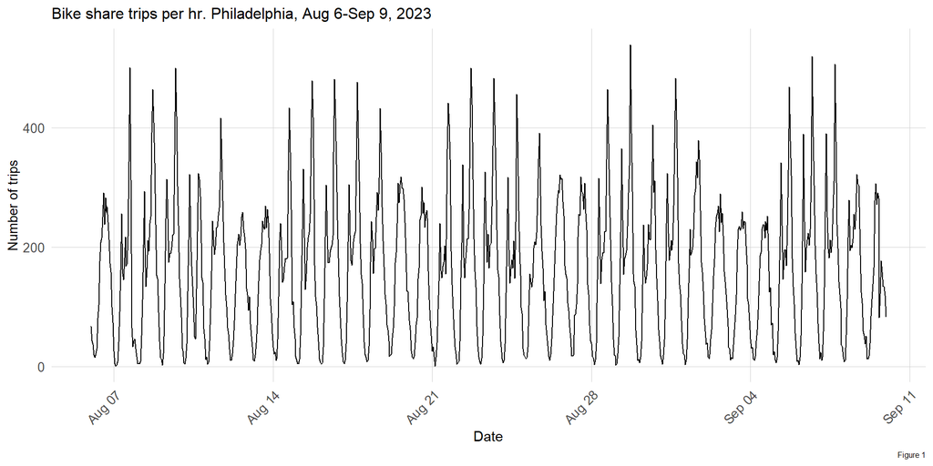

```r
ggplot(dat_census %>%
         group_by(interval60) %>%
         tally())+
  geom_line(aes(x = interval60, y = n))+
  labs(title="Bike share trips per hr. Philadelphia, Aug 6-Sep 9, 2023",
       x="Date",
       y="Number of trips",
       caption = "Figure 1")+
  plotTheme
```

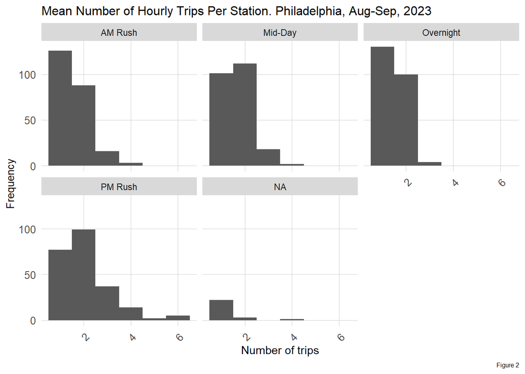

```r
dat_census %>%
        mutate(time_of_day = case_when(hour(interval60) < 7 | hour(interval60) > 18 ~ "Overnight",
                                 hour(interval60) >= 7 & hour(interval60) < 10 ~ "AM Rush",
                                 hour(interval60) >= 10 & hour(interval60) < 15 ~ "Mid-Day",
                                 hour(interval60) >= 15 & hour(interval60) <= 18 ~ "PM Rush"))%>%
         group_by(interval60, start_station, time_of_day) %>%
         tally()%>%
  group_by(start_station, time_of_day)%>%
  summarize(mean_trips = mean(n))%>%
  ggplot()+
  geom_histogram(aes(mean_trips), binwidth = 1)+
  labs(title="Mean Number of Hourly Trips Per Station. Philadelphia, Aug-Sep, 2023",
       x="Number of trips",
       y="Frequency",
       caption = "Figure 2")+
  facet_wrap(~time_of_day)+
  plotTheme
```

Figure 2 looks at the distribution of hourly rides per station, broken up by major periods of the day. In general, most stations see low ridership levels per hour, although there is more activity mid-day and during the PM rush. In addition to particular days of the week, this shows that re-balancing will be needed most during mid-day and PM peak periods when demand for bikes is highest.

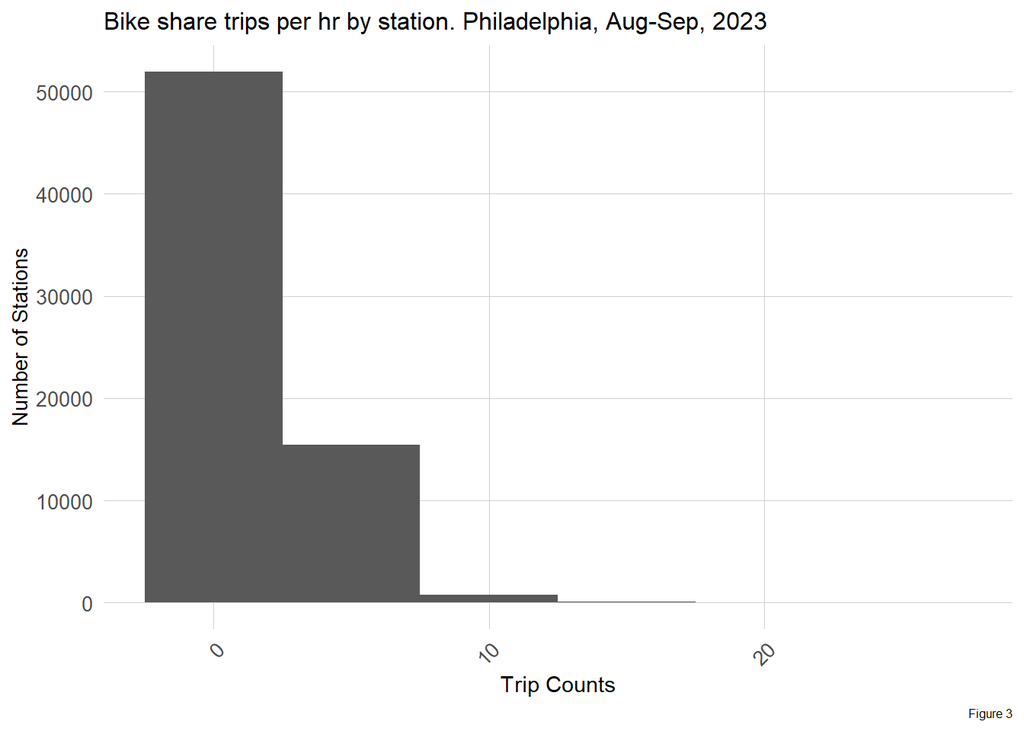

```r
ggplot(dat_census %>%
         group_by(interval60, start_station) %>%
         tally())+
  geom_histogram(aes(n), binwidth = 5)+
  labs(title="Bike share trips per hr by station. Philadelphia, Aug-Sep, 2023",
       x="Trip Counts",
       y="Number of Stations",
       caption = "Figure 3")+
  plotTheme
```

Figure 3 shows the distribution of hourly rides per station aggregated over the entire time period. As in the previous figure, it indicates that most stations see low levels of ridership most of the time.

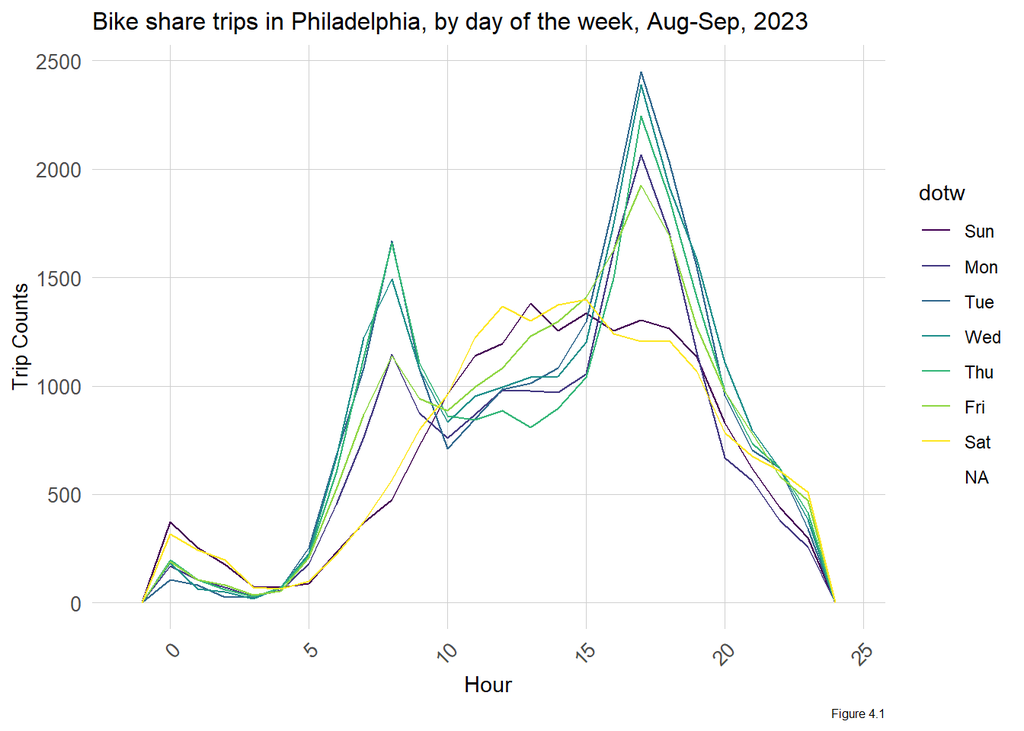

```r
ggplot(dat_census %>% mutate(hour = hour(timestamp)))+
     geom_freqpoly(aes(hour, color = dotw), binwidth = 1)+
  labs(title="Bike share trips in Philadelphia, by day of the week, Aug-Sep, 2023",
       x="Hour",
       y="Trip Counts",
       caption = "Figure 4.1")+
     plotTheme
```

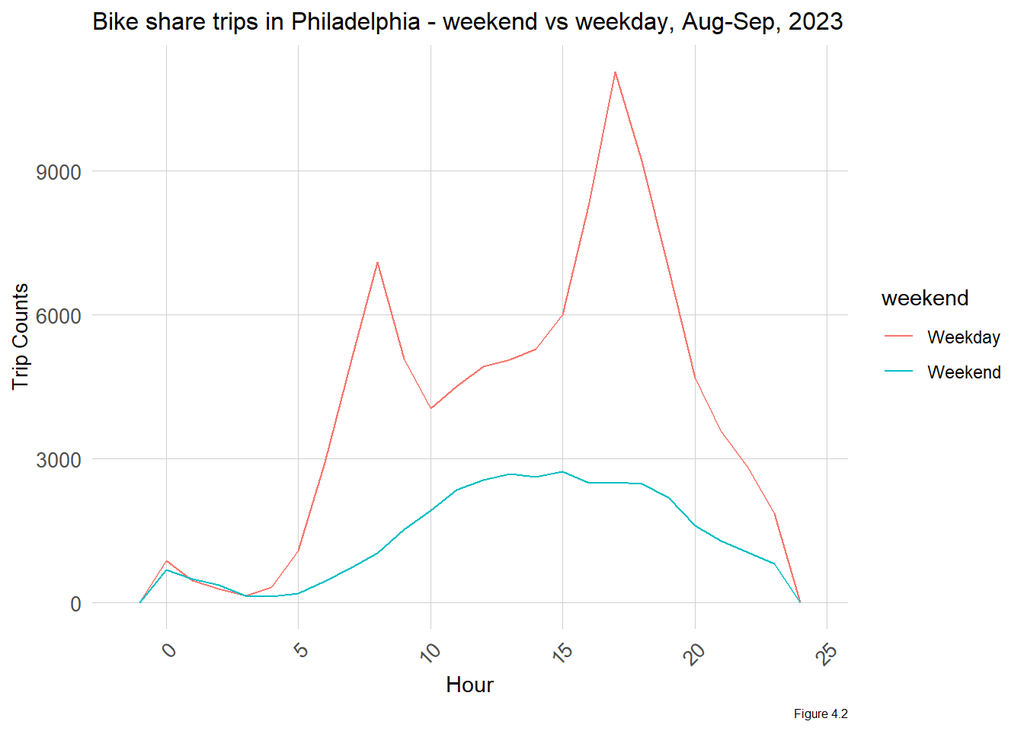

```r
ggplot(dat_census %>%
         mutate(hour = hour(timestamp),
                weekend = ifelse(dotw %in% c("Sun", "Sat"), "Weekend", "Weekday")))+
     geom_freqpoly(aes(hour, color = weekend), binwidth = 1)+
  labs(title="Bike share trips in Philadelphia - weekend vs weekday, Aug-Sep, 2023",
       x="Hour",
       y="Trip Counts",
       caption = "Figure 4.2")+
     plotTheme
```

Figures 4.1 shows the frequency of trips throughout the day for each day of the week, while Figure 4.2 aggregates this to weekdays and weekends. During the week there is a concentration of ridership during the peak commute periods, especially the PM peak. Ridership is more evenly distributed on the weekends, though it peaks at mid-day. The demand spike during the AM peak is not reflected in Figure 2, indicating that trip origins are more dispersed, meaning that despite high ridership most individual stations see low demand. Empty stations during the AM peak should be less of a concern then. The overall lower ridership on weekends means re-balancing efforts are best focused on weekdays.

### 2.2 Exploring Space-Time Dependencies of Ridership

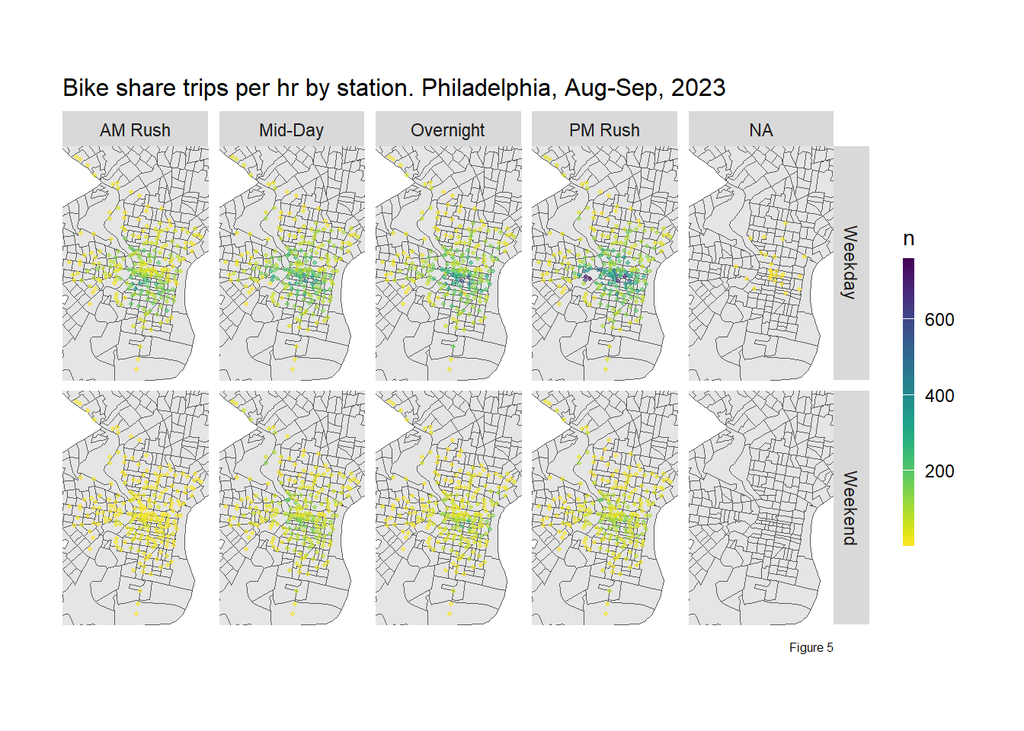

```r
ggplot()+
  geom_sf(data = tracts %>%
          st_transform(crs=4326))+
  geom_point(data= dat_census %>%
            mutate(hour = hour(timestamp),
                weekend = ifelse(dotw %in% c("Sun", "Sat"), "Weekend", "Weekday"),
                time_of_day = case_when(hour(interval60) < 7 | hour(interval60) > 18 ~ "Overnight",
                                 hour(interval60) >= 7 & hour(interval60) < 10 ~ "AM Rush",
                                 hour(interval60) >= 10 & hour(interval60) < 15 ~ "Mid-Day",
                                 hour(interval60) >= 15 & hour(interval60) <= 18 ~ "PM Rush"))%>%
              group_by(start_station, start_lat, start_lon, weekend, time_of_day) %>%
              tally(),
            aes(x=start_lon, y = start_lat, color = n),
            fill = "transparent", alpha = 0.6, size = 0.8)+
  scale_colour_viridis(direction = -1,
  discrete = FALSE, option = "D")+
  ylim(min(dat_census$start_lat), max(dat_census$start_lat))+
  xlim(min(dat_census$start_lon), max(dat_census$start_lon))+
  facet_grid(weekend ~ time_of_day)+
  labs(title="Bike share trips per hr by station. Philadelphia, Aug-Sep, 2023",
       caption = "Figure 5")+
  mapTheme
```

Figure 5 adds a spatial dimension to the data, and shows the distribution of trip origins during different periods of the day, divided by weekdays and weekends. This distribution is clearest on weekdays. In general, there is higher ridership in Center City, where population density is greatest. In addition, as posited under Figure 4, rides appear to be originating from more dispersed during the morning and mid-day. Many people appear to be riding into Center City and University City, two major employment centers, during these times, and thus are leaving from the same place during the PM peak, causing an even greater concentration of ridership in these areas. This plots indicates shows that re-balancing efforts should focus on having sufficiently empty stations in Center and University Cities early in the day for the arrivals, and that they are well stocked in the evening for everyone riding back to their respective neighborhoods.

### 2.3 Incorporating Weather Data

Another temporal feature to add is weather, as adverse conditions (rain, extreme temperatures, etc.) may discourage bike riding, and vice versa. I take the precipitation, wind speed, temperature and humidity (and calculate the heat index) for each hour during the study period, as recorded at the Philadelphia International Airport.

```r
weather.Panel <-
  riem_measures(station = "PHL", date_start = "2023-08-06", date_end = "2023-09-09") %>%
  dplyr::select(valid, tmpf, p01i, sknt, relh)%>%
  replace(is.na(.), 0) %>%
    mutate(interval60 = ymd_h(substr(valid,1,13))) %>%
    mutate(week = week(interval60),
           dotw = wday(interval60, label=TRUE)) %>%
    group_by(interval60) %>%
    summarize(Temperature = max(tmpf),
              Precipitation = sum(p01i),
              Wind_Speed = max(sknt),
              Humidity = max(relh),
              Heat_Index = ifelse(Temperature >= 80,-42.379 + 2.04901523 * Temperature + 10.14333127 * Humidity -
                0.22475541 * Temperature * Humidity
              - 0.00683783 * Temperature^2 - 0.05481717 * Humidity^2 + 0.00122874 *
                Temperature^2 * Humidity + 0.00085282 * Temperature
              * Humidity^2 - 0.00000199 * Temperature^2 * Humidity^2, Temperature)) %>%
    mutate(Temperature = ifelse(Temperature == 0, 42, Temperature))

#glimpse(weather.Panel)
```

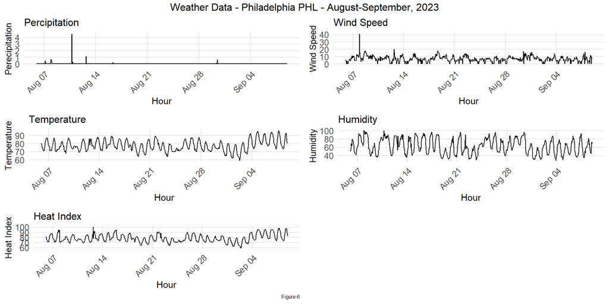

```r
grid.arrange(
  ggplot(weather.Panel, aes(interval60,Precipitation)) + geom_line() +
  labs(title="Percipitation", x="Hour", y="Perecipitation") + plotTheme,
  ggplot(weather.Panel, aes(interval60,Wind_Speed)) + geom_line() +
    labs(title="Wind Speed", x="Hour", y="Wind Speed") + plotTheme,
  ggplot(weather.Panel, aes(interval60,Temperature)) + geom_line() +
    labs(title="Temperature", x="Hour", y="Temperature") + plotTheme,
  ggplot(weather.Panel, aes(interval60,Humidity)) + geom_line() +
    labs(title="Humidity", x="Hour", y="Humidity") + plotTheme,
    ggplot(weather.Panel, aes(interval60,Heat_Index)) + geom_line() +
    labs(title="Heat Index", x="Hour", y="Heat Index",
         caption = "Figure 6") + plotTheme,
  top="Weather Data - Philadelphia PHL - August-September, 2023")
```

Figure 6 shows the changing weather conditions over the study period. There appears to be only one major storm, in early august, and a heatwave during the final week.

### 2.4 Creating Panel Data

In order to incorporate weather and time lag features (to be created below), the ridership data is re-organized into panel form, creating a separate row for each bike station for every hour of the study period and aggregating the trip data to each station-hour.

```r
#unique hours and unique stations
#length(unique(dat_census$interval60)) * length(unique(dat_census$start_station))


study.panel <-
  expand.grid(interval60=unique(dat_census$interval60),
              start_station = unique(dat_census$start_station)) %>%
  left_join(., dat_census %>%
              select(start_station, Origin.Tract, start_lon, start_lat)%>%
              distinct() %>%
              group_by(start_station) %>%
              slice(1))

#nrow(study.panel)
```

```r
ride.panel <-
  dat_census %>%
  mutate(Trip_Counter = 1) %>%
  right_join(study.panel) %>%
  group_by(interval60, start_station, Origin.Tract, start_lon, start_lat) %>%
  summarize(Trip_Count = sum(Trip_Counter, na.rm=T)) %>%
  left_join(weather.Panel) %>%
  ungroup() %>%
  filter(is.na(start_station) == FALSE) %>%
  mutate(week = week(interval60),
         dotw = wday(interval60, label = TRUE)) %>%
  filter(is.na(Origin.Tract) == FALSE)
```

```r
ride.panel <-
  left_join(ride.panel, census %>%
              as.data.frame() %>%
              select(-geometry), by = c("Origin.Tract" = "GEOID"))
```

### 2.5 Engineering Time Lag Features

As seen in the exploratory analysis, ridership levels show a cyclical process throughout the hours of the day and days of the week. Thus, ridership at a station an hour before, or a day before, may be a good predictor for ridership at the time in question. I create lag features for 1, 2 , 3, 4, 12, and 24 hours beforehand. I also create a holiday lag feature based on proximity to Labor Day.

```r
ride.panel <-
  ride.panel %>%
  arrange(start_station, interval60) %>%
  mutate(lagHour = dplyr::lag(Trip_Count,1),
         lag2Hours = dplyr::lag(Trip_Count,2),
         lag3Hours = dplyr::lag(Trip_Count,3),
         lag4Hours = dplyr::lag(Trip_Count,4),
         lag12Hours = dplyr::lag(Trip_Count,12),
         lag1day = dplyr::lag(Trip_Count,24),
         holiday = ifelse(yday(interval60) == 247,1,0)) %>%
   mutate(day = yday(interval60)) %>%
   mutate(holidayLag = case_when(dplyr::lag(holiday, 1) == 1 ~ "PlusOneDay",
                                 dplyr::lag(holiday, 2) == 1 ~ "PlustTwoDays",
                                 dplyr::lag(holiday, 3) == 1 ~ "PlustThreeDays",
                                 dplyr::lead(holiday, 1) == 1 ~ "MinusOneDay",
                                 dplyr::lead(holiday, 2) == 1 ~ "MinusTwoDays",
                                 dplyr::lead(holiday, 3) == 1 ~ "MinusThreeDays"),
         holidayLag = ifelse(is.na(holidayLag) == TRUE, 0, holidayLag))
```

```r
kable(as.data.frame(ride.panel) %>%
    group_by(interval60) %>%
    summarise_at(vars(starts_with("lag"), "Trip_Count"), mean, na.rm = TRUE) %>%
    gather(Variable, Value, -interval60, -Trip_Count) %>%
    mutate(Variable = factor(Variable, levels=c("lagHour","lag2Hours","lag3Hours","lag4Hours",
                                                "lag12Hours","lag1day")))%>%
    group_by(Variable) %>%
    summarize(correlation = round(cor(Value, Trip_Count),2)),
    caption = "Figure 7: Time Lag Correlation with Present Ridership") %>% kable_styling()
```

Figure 7: Time Lag Correlation with Present Ridership

| Variable | correlation |
| --- | --- |
| lagHour | 0.87 |
| lag2Hours | 0.65 |
| lag3Hours | 0.43 |
| lag4Hours | 0.23 |
| lag12Hours | -0.58 |
| lag1day | 0.88 |

Figure 7 shows the correlation between different time lags and present ridership. Within a single day, ridership is more correlated with more recent previous ridership, although ridership at the same time in the previous day is also significantly correlated. This is also reflected in previous plots, which show recurring ridership trends over different times of the day. While I posited a 2 hour lag as appropriate for re-balancing efforts, it looks like a 24 hour lag will be a better predictor. The 24 hour lag would also be more useful for the workers tasked with re-balancing, as they can start the day already having a good idea of which stations will be in demand and which won’t.

### 2.6 Engineering Spatial Amenity Features

Other spatial features that could affect ridership are amenities near bike stations. I created two amenity features: parks.Buffer, which is a count of city parks within a half-mile of each bike station, and nearest neighbor scores (k=1 to k=5) for SEPTA rail stations around each bike station.

```r
parks <-
  st_read("https://opendata.arcgis.com/datasets/d52445160ab14380a673e5849203eb64_0.geojson",
          quiet = TRUE) %>%
  st_transform('ESRI:102729')

parks4buff <- parks %>% dplyr::select(geometry)

#parks within 1/2 mile
ride.panel$parks.Buffer <- ride.panel %>%
    st_as_sf(., coords = c("start_lon", "start_lat"), crs = 4326) %>%
    st_transform('ESRI:102729') %>%
    st_buffer(2640) %>%
    aggregate(mutate(parks4buff, counter = 1),., sum) %>%
    pull(counter)

ride.panel <- ride.panel %>% mutate(parks.Buffer = replace_na(parks.Buffer, 0))

subway <- st_read("Highspeed_Stations.geojson", quiet = TRUE) %>%
  st_transform('ESRI:102729') %>%
  dplyr::select(geometry)
trolley <- st_read("Trolley_Stations.geojson", quiet = TRUE) %>%
  st_transform('ESRI:102729') %>%
  dplyr::select(geometry)
rr <- st_read("Regional_Rail_Stations.geojson", quiet = TRUE) %>%
  st_transform('ESRI:102729') %>%
  dplyr::select(geometry)
septa <- rbind(subway, trolley, rr)

ride.panel <-
  ride.panel %>%
  st_as_sf(., coords = c("start_lon", "start_lat"), crs = 4326, remove=FALSE) %>%
  st_transform('ESRI:102729')

ride.panel <-
  ride.panel %>%
    mutate(
      septa_nn1 = nn_function(st_coordinates(ride.panel),
                              st_coordinates(septa), k = 1),

      septa_nn2 = nn_function(st_coordinates(ride.panel),
                              st_coordinates(septa), k = 2),

      septa_nn3 = nn_function(st_coordinates(ride.panel),
                              st_coordinates(septa), k = 3),

      septa_nn4 = nn_function(st_coordinates(ride.panel),
                              st_coordinates(septa), k = 4),

      septa_nn5 = nn_function(st_coordinates(ride.panel),
                              st_coordinates(septa), k = 5))

ride.panel <- ride.panel %>%
  st_drop_geometry()
```

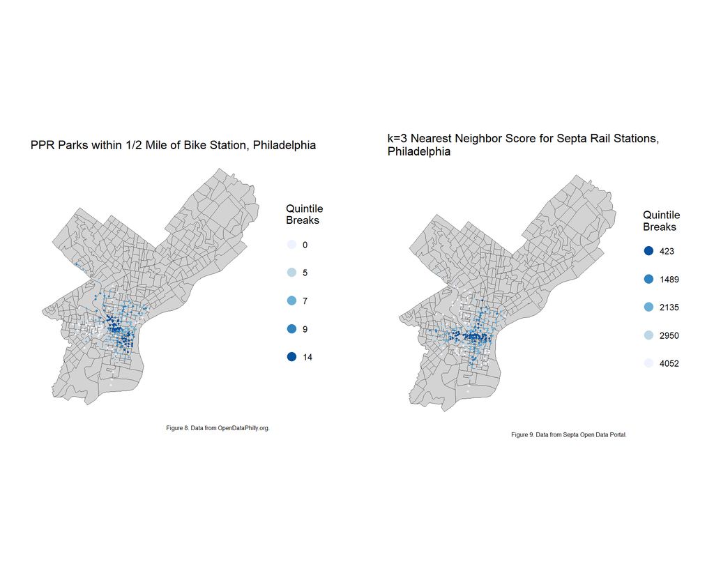

```r
grid.arrange(ncol=2,
ggplot() +
  geom_sf(data = tracts %>%
          st_transform(crs=4326) , fill = "lightgray") +
  geom_sf(data = ride.panel %>% group_by(start_station) %>%
            st_as_sf(., coords = c("start_lon", "start_lat"), crs = 4326, remove=FALSE),
          aes(colour = q5(parks.Buffer)),
          show.legend = "point", size = .75) +
  scale_colour_manual(values = palette5,
                   labels=qBr(ride.panel,"parks.Buffer"),
                   name="Quintile\nBreaks") +
  labs(title="PPR Parks within 1/2 Mile of Bike Station, Philadelphia",
       caption = "Figure 8. Data from OpenDataPhilly.org.") +

  mapTheme +
  guides(colour = guide_legend(override.aes = list(size=4))),

ggplot() +
  geom_sf(data = tracts %>%
          st_transform(crs=4326) , fill = "lightgray") +
  geom_sf(data = ride.panel %>% group_by(start_station) %>%
            st_as_sf(., coords = c("start_lon", "start_lat"), crs = 4326, remove=FALSE),
          aes(colour = q5(septa_nn3)),
          show.legend = "point", size = .75) +
  scale_colour_manual(values = palette5_2,
                   labels=qBr(ride.panel,"septa_nn3"),
                   name="Quintile\nBreaks") +
  labs(title="k=3 Nearest Neighbor Score for Septa Rail Stations,\nPhiladelphia",
       caption = "Figure 9. Data from Septa Open Data Portal.") +
  mapTheme +
  guides(colour = guide_legend(override.aes = list(size=4))))
```

Figures 8 and 9 show the values of our amenity features, distance to parks and rail transit, at each Indego bike station. Like with bike ridership (see Figure 5), the highest values cluster around Center City.

```r
# ggplot(ride.panel %>%
#          group_by(Temperature) %>%
#          summarise(count = sum(Trip_Count))) +
#   geom_point(aes(x = Temperature, y = count))+
#   labs(title="Bike share trips per temperature, Philadelphia, Aug-Sep, 2023",
#        x="Temperature",
#        y="Number of trips")+
#   plotTheme
```

## 3. Regression Modeling

### 3.1 Creating the Models

```r
ride.Train <- filter(ride.panel, week >= 34)
ride.Test <- filter(ride.panel, week < 34)
```

```r
reg1 <-
  lm(Trip_Count ~  hour(interval60) + dotw + Heat_Index,  data=ride.Train)

reg2 <-
  lm(Trip_Count ~  start_station + dotw + Heat_Index + parks.Buffer + septa_nn3,  data=ride.Train)

reg3 <-
  lm(Trip_Count ~  start_station + hour(interval60) + dotw + Heat_Index + Precipitation +
       parks.Buffer + septa_nn3,
     data=ride.Train)

reg4 <-
  lm(Trip_Count ~  start_station +  hour(interval60) + dotw + Heat_Index + Precipitation +
       parks.Buffer + septa_nn3 +
                   lagHour + lag2Hours + lag1day,
     data=ride.Train)

reg5 <-
  lm(Trip_Count ~  start_station + hour(interval60) + dotw + Heat_Index + Precipitation +
       parks.Buffer + septa_nn3 +
                   lagHour + lag2Hours + lag1day + holidayLag + holiday,
     data=ride.Train)

reg.list <- list(reg1, reg2, reg3)


summary(reg1)
```

```
##
## Call:
## lm(formula = Trip_Count ~ hour(interval60) + dotw + Heat_Index,
##     data = ride.Train)
##
## Residuals:
##     Min      1Q  Median      3Q     Max
## -1.2081 -0.7507 -0.4063  0.2660 25.0190
##
## Coefficients:
##                    Estimate Std. Error t value Pr(>|t|)
## (Intercept)       0.2537450  0.0392777   6.460 1.05e-10 ***
## hour(interval60)  0.0379544  0.0006476  58.610  < 2e-16 ***
## dotw.L            0.0466551  0.0110016   4.241 2.23e-05 ***
## dotw.Q           -0.1294125  0.0109402 -11.829  < 2e-16 ***
## dotw.C            0.0054912  0.0106163   0.517  0.60499
## dotw^4            0.0304653  0.0103152   2.953  0.00314 **
## dotw^5           -0.0263743  0.0101744  -2.592  0.00954 **
## dotw^6            0.0188875  0.0101311   1.864  0.06228 .
## Heat_Index        0.0002138  0.0005397   0.396  0.69202
## ---
## Signif. codes:  0 '***' 0.001 '**' 0.01 '*' 0.05 '.' 0.1 ' ' 1
##
## Residual standard error: 1.314 on 112077 degrees of freedom
##   (5616 observations deleted due to missingness)
## Multiple R-squared:  0.04022,    Adjusted R-squared:  0.04015
## F-statistic: 587.1 on 8 and 112077 DF,  p-value: < 2.2e-16
```

```r
print("Figure 10.1: Time regression results")
```

```
## [1] "Figure 10.1: Time regression results"
```

```r
summary(reg2)
```

```
##
## Call:
## lm(formula = Trip_Count ~ start_station + dotw + Heat_Index +
##     parks.Buffer + septa_nn3, data = ride.Train)
##
## Residuals:
##     Min      1Q  Median      3Q     Max
## -1.7116 -0.7531 -0.3772  0.2582 24.7313
##
## Coefficients:
##                 Estimate Std. Error t value Pr(>|t|)
## (Intercept)    4.798e+00  1.200e-01  40.001  < 2e-16 ***
## start_station -1.621e-03  3.585e-05 -45.214  < 2e-16 ***
## dotw.L         8.375e-02  1.083e-02   7.732 1.07e-14 ***
## dotw.Q        -9.004e-02  1.077e-02  -8.361  < 2e-16 ***
## dotw.C        -2.672e-02  1.046e-02  -2.555   0.0106 *
## dotw^4         4.735e-02  1.017e-02   4.656 3.22e-06 ***
## dotw^5        -1.399e-02  1.003e-02  -1.395   0.1631
## dotw^6         2.363e-02  9.991e-03   2.365   0.0180 *
## Heat_Index     1.544e-02  4.665e-04  33.111  < 2e-16 ***
## parks.Buffer   1.788e-02  6.541e-04  27.333  < 2e-16 ***
## septa_nn3     -1.046e-04  2.183e-06 -47.926  < 2e-16 ***
## ---
## Signif. codes:  0 '***' 0.001 '**' 0.01 '*' 0.05 '.' 0.1 ' ' 1
##
## Residual standard error: 1.296 on 112075 degrees of freedom
##   (5616 observations deleted due to missingness)
## Multiple R-squared:  0.06658,    Adjusted R-squared:  0.06649
## F-statistic: 799.4 on 10 and 112075 DF,  p-value: < 2.2e-16
```

```r
print("Figure 10.2: Space regression results")
```

```
## [1] "Figure 10.2: Space regression results"
```

```r
summary(reg3)
```

```
##
## Call:
## lm(formula = Trip_Count ~ start_station + hour(interval60) +
##     dotw + Heat_Index + Precipitation + parks.Buffer + septa_nn3,
##     data = ride.Train)
##
## Residuals:
##     Min      1Q  Median      3Q     Max
## -1.8447 -0.7213 -0.3279  0.2647 24.7252
##
## Coefficients:
##                    Estimate Std. Error t value Pr(>|t|)
## (Intercept)       5.545e+00  1.187e-01  46.711  < 2e-16 ***
## start_station    -1.621e-03  3.528e-05 -45.945  < 2e-16 ***
## hour(interval60)  3.791e-02  6.287e-04  60.294  < 2e-16 ***
## dotw.L            4.662e-02  1.068e-02   4.367 1.26e-05 ***
## dotw.Q           -1.274e-01  1.064e-02 -11.973  < 2e-16 ***
## dotw.C            5.652e-03  1.030e-02   0.549  0.58333
## dotw^4            2.877e-02  1.003e-02   2.869  0.00412 **
## dotw^5           -2.649e-02  9.874e-03  -2.682  0.00731 **
## dotw^6            2.125e-02  9.871e-03   2.153  0.03132 *
## Heat_Index        2.721e-04  5.242e-04   0.519  0.60371
## Precipitation     3.374e-01  1.249e-01   2.702  0.00689 **
## parks.Buffer      1.788e-02  6.437e-04  27.775  < 2e-16 ***
## septa_nn3        -1.046e-04  2.149e-06 -48.700  < 2e-16 ***
## ---
## Signif. codes:  0 '***' 0.001 '**' 0.01 '*' 0.05 '.' 0.1 ' ' 1
##
## Residual standard error: 1.275 on 112073 degrees of freedom
##   (5616 observations deleted due to missingness)
## Multiple R-squared:  0.09605,    Adjusted R-squared:  0.09596
## F-statistic: 992.4 on 12 and 112073 DF,  p-value: < 2.2e-16
```

```r
print("Figure 10.3: Space-time regression results")
```

```
## [1] "Figure 10.3: Space-time regression results"
```

```r
summary(reg4)
```

```
##
## Call:
## lm(formula = Trip_Count ~ start_station + hour(interval60) +
##     dotw + Heat_Index + Precipitation + parks.Buffer + septa_nn3 +
##     lagHour + lag2Hours + lag1day, data = ride.Train)
##
## Residuals:
##     Min      1Q  Median      3Q     Max
## -7.3523 -0.4758 -0.1914  0.1936 23.8873
##
## Coefficients:
##                    Estimate Std. Error t value Pr(>|t|)
## (Intercept)       2.012e+00  1.040e-01  19.350  < 2e-16 ***
## start_station    -5.421e-04  3.094e-05 -17.520  < 2e-16 ***
## hour(interval60)  9.735e-03  5.630e-04  17.293  < 2e-16 ***
## dotw.L           -1.177e-04  9.212e-03  -0.013 0.989807
## dotw.Q           -7.517e-02  9.185e-03  -8.184 2.78e-16 ***
## dotw.C            3.435e-02  8.889e-03   3.865 0.000111 ***
## dotw^4           -3.912e-04  8.652e-03  -0.045 0.963935
## dotw^5           -1.848e-02  8.516e-03  -2.170 0.030026 *
## dotw^6            2.194e-02  8.514e-03   2.577 0.009972 **
## Heat_Index       -1.449e-03  4.525e-04  -3.203 0.001362 **
## Precipitation     3.284e-01  1.077e-01   3.050 0.002291 **
## parks.Buffer      5.749e-03  5.587e-04  10.290  < 2e-16 ***
## septa_nn3        -3.586e-05  1.888e-06 -18.998  < 2e-16 ***
## lagHour           2.381e-01  2.936e-03  81.104  < 2e-16 ***
## lag2Hours         1.289e-01  2.876e-03  44.838  < 2e-16 ***
## lag1day           2.987e-01  2.796e-03 106.828  < 2e-16 ***
## ---
## Signif. codes:  0 '***' 0.001 '**' 0.01 '*' 0.05 '.' 0.1 ' ' 1
##
## Residual standard error: 1.1 on 112070 degrees of freedom
##   (5616 observations deleted due to missingness)
## Multiple R-squared:  0.3277, Adjusted R-squared:  0.3276
## F-statistic:  3641 on 15 and 112070 DF,  p-value: < 2.2e-16
```

```r
print("Figure 10.4: Time-lag regression results")
```

```
## [1] "Figure 10.4: Time-lag regression results"
```

```r
summary(reg5)
```

```
##
## Call:
## lm(formula = Trip_Count ~ start_station + hour(interval60) +
##     dotw + Heat_Index + Precipitation + parks.Buffer + septa_nn3 +
##     lagHour + lag2Hours + lag1day + holidayLag + holiday, data = ride.Train)
##
## Residuals:
##     Min      1Q  Median      3Q     Max
## -7.3325 -0.4767 -0.1921  0.1957 23.8716
##
## Coefficients:
##                            Estimate Std. Error t value Pr(>|t|)
## (Intercept)               1.961e+00  1.041e-01  18.831  < 2e-16 ***
## start_station            -5.447e-04  3.093e-05 -17.608  < 2e-16 ***
## hour(interval60)          9.268e-03  5.716e-04  16.214  < 2e-16 ***
## dotw.L                   -1.593e-02  9.502e-03  -1.677 0.093573 .
## dotw.Q                   -7.019e-02  9.239e-03  -7.596 3.07e-14 ***
## dotw.C                    4.317e-02  9.237e-03   4.673 2.97e-06 ***
## dotw^4                   -1.169e-02  9.302e-03  -1.256 0.208977
## dotw^5                   -1.187e-02  8.982e-03  -1.322 0.186221
## dotw^6                    2.176e-02  8.635e-03   2.520 0.011724 *
## Heat_Index               -5.148e-04  4.660e-04  -1.105 0.269297
## Precipitation             3.375e-01  1.077e-01   3.135 0.001719 **
## parks.Buffer              5.778e-03  5.585e-04  10.345  < 2e-16 ***
## septa_nn3                -3.603e-05  1.887e-06 -19.090  < 2e-16 ***
## lagHour                   2.375e-01  2.936e-03  80.874  < 2e-16 ***
## lag2Hours                 1.284e-01  2.876e-03  44.634  < 2e-16 ***
## lag1day                   2.983e-01  2.796e-03 106.721  < 2e-16 ***
## holidayLagMinusOneDay    -2.974e-01  5.949e-02  -4.998 5.79e-07 ***
## holidayLagMinusThreeDays -2.554e-01  7.264e-02  -3.516 0.000438 ***
## holidayLagMinusTwoDays   -2.021e-01  7.266e-02  -2.782 0.005403 **
## holidayLagPlusOneDay     -2.371e-01  5.950e-02  -3.985 6.75e-05 ***
## holidayLagPlustThreeDays -2.390e-01  7.290e-02  -3.279 0.001042 **
## holidayLagPlustTwoDays   -1.918e-01  7.303e-02  -2.627 0.008626 **
## holiday                   1.570e-01  6.083e-02   2.580 0.009868 **
## ---
## Signif. codes:  0 '***' 0.001 '**' 0.01 '*' 0.05 '.' 0.1 ' ' 1
##
## Residual standard error: 1.099 on 112063 degrees of freedom
##   (5616 observations deleted due to missingness)
## Multiple R-squared:  0.3282, Adjusted R-squared:  0.328
## F-statistic:  2488 on 22 and 112063 DF,  p-value: < 2.2e-16
```

```r
print("Figure 10.5: Time-lag regression w/ holiday lag results")
```

```
## [1] "Figure 10.5: Time-lag regression w/ holiday lag results"
```

### 3.2 Accuracy and Error

```r
ride.Test.weekNest <-
  ride.Test %>%
  nest(-week)
```

```r
model_pred <- function(dat, fit){
   pred <- predict(fit, newdata = dat)}
```

```r
week_predictions <-
  ride.Test.weekNest %>%
    mutate(ATime_FE = map(.x = data, fit = reg1, .f = model_pred),
           BSpace_FE = map(.x = data, fit = reg2, .f = model_pred),
           CTime_Space_FE = map(.x = data, fit = reg3, .f = model_pred),
           DTime_Space_FE_timeLags = map(.x = data, fit = reg4, .f = model_pred),
           ETime_Space_FE_timeLags_holidayLags = map(.x = data, fit = reg5, .f = model_pred)) %>%
    gather(Regression, Prediction, -data, -week) %>%
    mutate(Observed = map(data, pull, Trip_Count),
           Absolute_Error = map2(Observed, Prediction,  ~ abs(.x - .y)),
           MAE = map_dbl(Absolute_Error, mean, na.rm = TRUE),
           sd_AE = map_dbl(Absolute_Error, sd, na.rm = TRUE))

#week_predictions
```

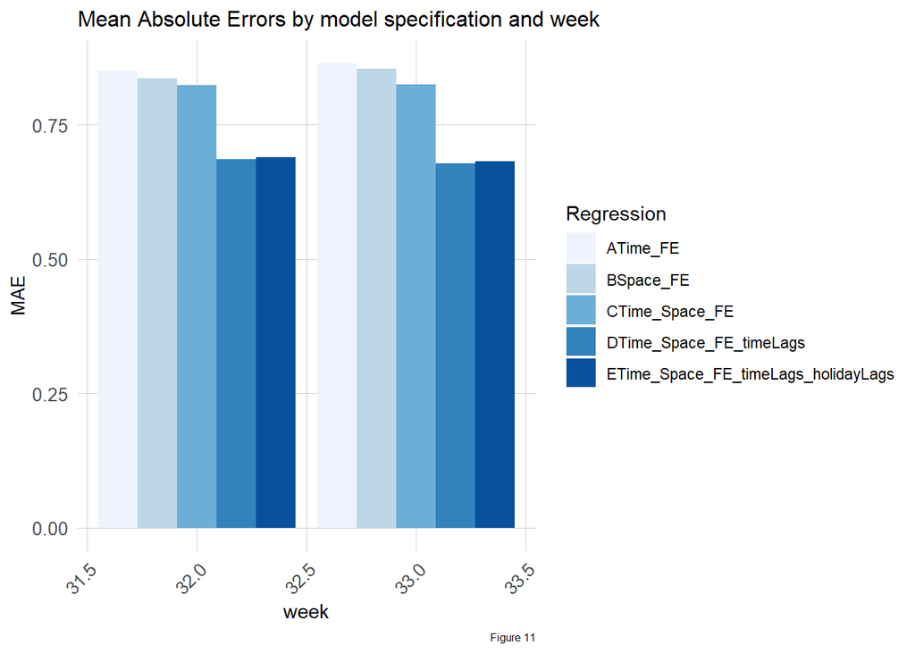

```r
week_predictions %>%
  dplyr::select(week, Regression, MAE) %>%
  gather(Variable, MAE, -Regression, -week) %>%
  ggplot(aes(week, MAE)) +
    geom_bar(aes(fill = Regression), position = "dodge", stat="identity") +
    scale_fill_manual(values = palette5) +
    labs(title = "Mean Absolute Errors by model specification and week",
         caption = "Figure 11") +
  plotTheme
```

Figure 11 shows the mean absolute error (MAE) for each regression model for each of the 2 test set weeks. Although combining space, time, and amenity features generated some improvement, incorporating the time-lag features generated the greatest accuracy. This reflects the cyclical nature of ride demand as seen in previous plots.

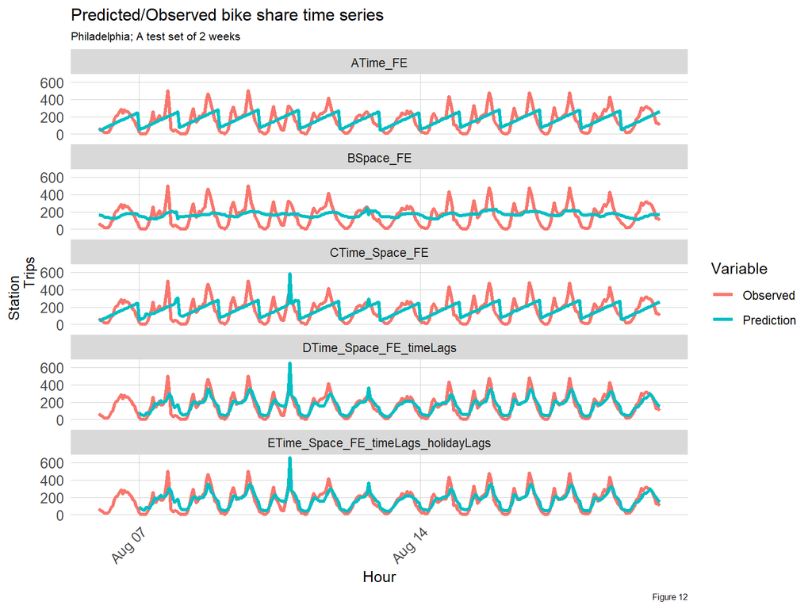

```r
week_predictions %>%
    mutate(interval60 = map(data, pull, interval60),
           start_station = map(data, pull, start_station)) %>%
    dplyr::select(interval60, start_station, Observed, Prediction, Regression) %>%
    unnest() %>%
    gather(Variable, Value, -Regression, -interval60, -start_station) %>%
    group_by(Regression, Variable, interval60) %>%
    summarize(Value = sum(Value)) %>%
    ggplot(aes(interval60, Value, colour=Variable)) +
      geom_line(size = 1.1) +
      facet_wrap(~Regression, ncol=1) +
      labs(title = "Predicted/Observed bike share time series", subtitle = "Philadelphia; A test set of 2 weeks",  x = "Hour", y= "Station
           Trips",
           caption = "Figure 12") +
      plotTheme
```

Figure 12 compares the predictions of each model to the observed ridership over the entire study area. The models incorporating time-lag features most closely follow the actual trends, although they under-predict at the peak periods.

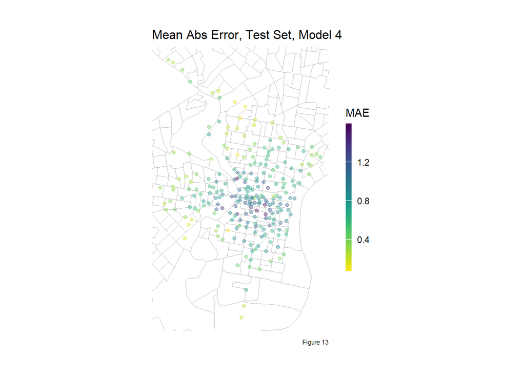

```r
week_predictions %>%
    mutate(interval60 = map(data, pull, interval60),
           start_station = map(data, pull, start_station),
           start_lat = map(data, pull, start_lat),
           start_lon = map(data, pull, start_lon)) %>%
    select(interval60, start_station, start_lon, start_lat, Observed, Prediction, Regression) %>%
    unnest() %>%
  filter(Regression == "DTime_Space_FE_timeLags") %>%
  group_by(start_station, start_lon, start_lat) %>%
  summarize(MAE = mean(abs(Observed-Prediction), na.rm = TRUE))%>%
ggplot(.)+
  geom_sf(data = census, color = "grey", fill = "transparent")+
  geom_point(aes(x = start_lon, y = start_lat, color = MAE),
             fill = "transparent", alpha = 0.4)+
  scale_colour_viridis(direction = -1,
  discrete = FALSE, option = "D")+
  ylim(min(dat_census$start_lat), max(dat_census$start_lat))+
  xlim(min(dat_census$start_lon), max(dat_census$start_lon))+
  labs(title="Mean Abs Error, Test Set, Model 4",
       caption = "Figure 13")+
  mapTheme
```

Figure 13 shows the MAE for each bike station using the “DTime_Space_FE_timeLags”, which has the lowest MAE overall. The highest error is seen in Center City, although this may be due more to the comparatively higher ridership in the neighborhood than a flaw in the model.

### 3.3 Space-Time Error Evaluation

I will now examine how well the model generalizes across time and space.

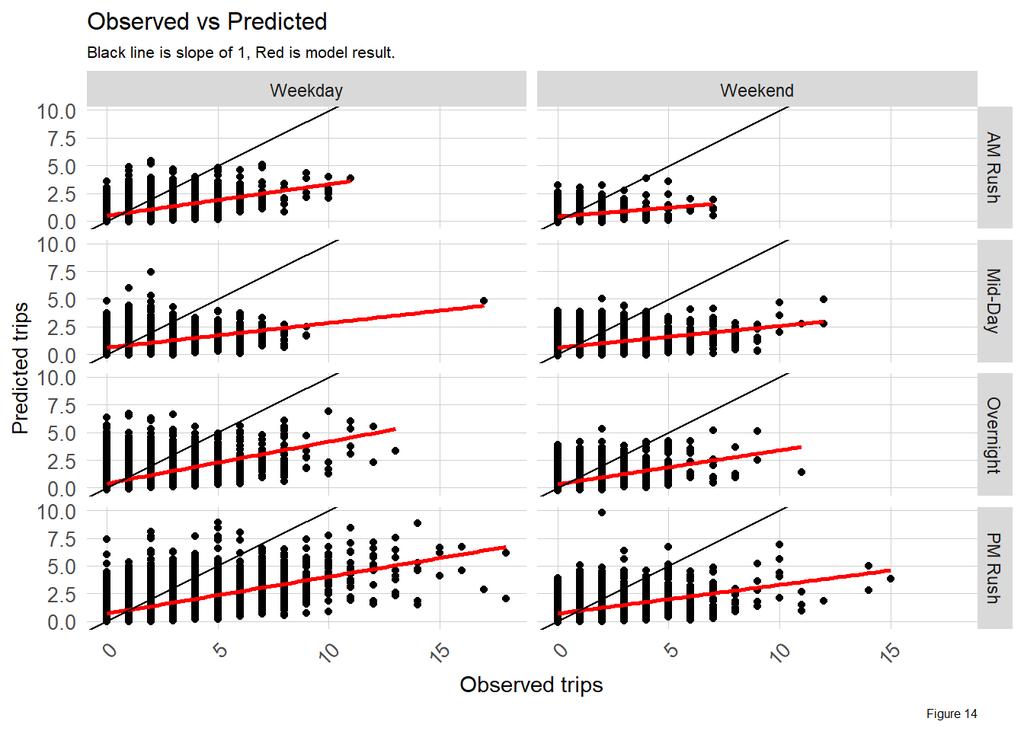

```r
week_predictions %>%
    mutate(interval60 = map(data, pull, interval60),
           start_station = map(data, pull, start_station),
           start_lat = map(data, pull, start_lat),
           start_lon = map(data, pull, start_lon),
           dotw = map(data, pull, dotw)) %>%
    select(interval60, start_station, start_lon,
           start_lat, Observed, Prediction, Regression,
           dotw) %>%
    unnest() %>%
  filter(Regression == "DTime_Space_FE_timeLags")%>%
  mutate(weekend = ifelse(dotw %in% c("Sun", "Sat"), "Weekend", "Weekday"),
         time_of_day = case_when(hour(interval60) < 7 | hour(interval60) > 18 ~ "Overnight",
                                 hour(interval60) >= 7 & hour(interval60) < 10 ~ "AM Rush",
                                 hour(interval60) >= 10 & hour(interval60) < 15 ~ "Mid-Day",
                                 hour(interval60) >= 15 & hour(interval60) <= 18 ~ "PM Rush"))%>%
  ggplot()+
  geom_point(aes(x= Observed, y = Prediction))+
    geom_smooth(aes(x= Observed, y= Prediction), method = "lm", se = FALSE, color = "red")+
    geom_abline(slope = 1, intercept = 0)+
  facet_grid(time_of_day~weekend)+
  labs(title="Observed vs Predicted",
       subtitle = "Black line is slope of 1, Red is model result.",
       x="Observed trips",
       y="Predicted trips",
       caption = "Figure 14")+
  plotTheme
```

Figure 14 shows the observed vs. predicted values for the time of day on weekdays and weekends. In all cases the model is mostly under-predicting ridership.

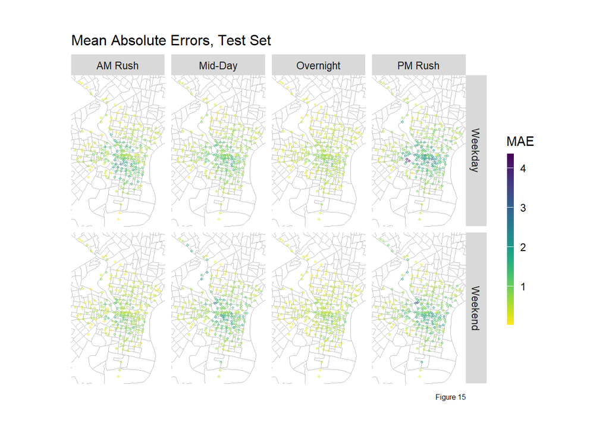

```r
week_predictions %>%
    mutate(interval60 = map(data, pull, interval60),
           start_station = map(data, pull, start_station),
           start_lat = map(data, pull, start_lat),
           start_lon = map(data, pull, start_lon),
           dotw = map(data, pull, dotw) ) %>%
    select(interval60, start_station, start_lon,
           start_lat, Observed, Prediction, Regression,
           dotw) %>%
    unnest() %>%
  filter(Regression == "DTime_Space_FE_timeLags")%>%
  mutate(weekend = ifelse(dotw %in% c("Sun", "Sat"), "Weekend", "Weekday"),
         time_of_day = case_when(hour(interval60) < 7 | hour(interval60) > 18 ~ "Overnight",
                                 hour(interval60) >= 7 & hour(interval60) < 10 ~ "AM Rush",
                                 hour(interval60) >= 10 & hour(interval60) < 15 ~ "Mid-Day",
                                 hour(interval60) >= 15 & hour(interval60) <= 18 ~ "PM Rush")) %>%
  group_by(start_station, weekend, time_of_day, start_lon, start_lat) %>%
  summarize(MAE = mean(abs(Observed-Prediction), na.rm = TRUE))%>%
  ggplot(.)+
  geom_sf(data = census, color = "grey", fill = "transparent")+
  geom_point(aes(x = start_lon, y = start_lat, color = MAE),
             fill = "transparent", size = 0.8, alpha = 0.4)+
  scale_colour_viridis(direction = -1,
  discrete = FALSE, option = "D")+
  ylim(min(dat_census$start_lat), max(dat_census$start_lat))+
  xlim(min(dat_census$start_lon), max(dat_census$start_lon))+
  facet_grid(weekend~time_of_day)+
  labs(title="Mean Absolute Errors, Test Set",
       caption = "Figure 15")+
  mapTheme
```

Figure 15 adds to Figure 14 by showing the spatial distribution of mean absolute error. Although MAE is low overall (see Figure 11), it is not evenly distributed. The highest errors are during the PM rush time, and are concentrated in Center City. This supports the trend seen in Figure 12, in which the model under-predicts during peak periods. Looking back at Figure 5, it is also clear that the model is under-predicting at stations with higher ridership.

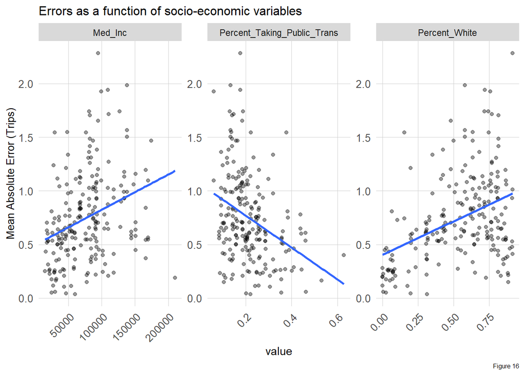

```r
week_predictions %>%
    mutate(interval60 = map(data, pull, interval60),
           start_station = map(data, pull, start_station),
           start_lat = map(data, pull, start_lat),
           start_lon = map(data, pull, start_lon),
           dotw = map(data, pull, dotw),
           Percent_Taking_Public_Trans = map(data, pull, Percent_Taking_Public_Trans),
           Med_Inc = map(data, pull, Med_Inc),
           Percent_White = map(data, pull, Percent_White)) %>%
    select(interval60, start_station, start_lon,
           start_lat, Observed, Prediction, Regression,
           dotw, Percent_Taking_Public_Trans, Med_Inc, Percent_White) %>%
    unnest() %>%
  filter(Regression == "DTime_Space_FE_timeLags")%>%
  mutate(weekend = ifelse(dotw %in% c("Sun", "Sat"), "Weekend", "Weekday"),
         time_of_day = case_when(hour(interval60) < 7 | hour(interval60) > 18 ~ "Overnight",
                                 hour(interval60) >= 7 & hour(interval60) < 10 ~ "AM Rush",
                                 hour(interval60) >= 10 & hour(interval60) < 15 ~ "Mid-Day",
                                 hour(interval60) >= 15 & hour(interval60) <= 18 ~ "PM Rush")) %>%
  filter(time_of_day == "AM Rush") %>%
  group_by(start_station, Percent_Taking_Public_Trans, Med_Inc, Percent_White) %>%
  summarize(MAE = mean(abs(Observed-Prediction), na.rm = TRUE))%>%
  gather(-start_station, -MAE, key = "variable", value = "value")%>%
  ggplot(.)+
  #geom_sf(data = chicagoCensus, color = "grey", fill = "transparent")+
  geom_point(aes(x = value, y = MAE), alpha = 0.4)+
  geom_smooth(aes(x = value, y = MAE), method = "lm", se= FALSE)+
  facet_wrap(~variable, scales = "free")+
  labs(title="Errors as a function of socio-economic variables",
       y="Mean Absolute Error (Trips)",
       caption = "Figure 16")+
  plotTheme
```

### 3.4 Cross-validation

The model is tested again using a 100-fold cross validation over time-based features.

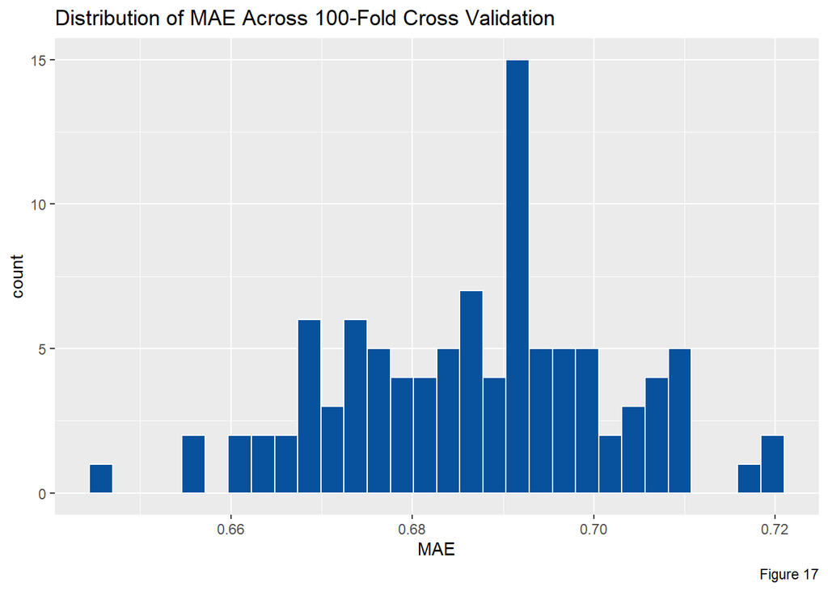

```r
# ## define the variables we want
# reg.vars <- c("start_station", "hour(interval60)", "dotw", "Heat_Index", "Precipitation",
#               "lagHour", "lag2Hours", "lag1day")
#
# ride.panel.cv <- ride.panel %>%
#   mutate(cvID = sample(round(nrow(ride.panel) / 100),
#                        size=nrow(ride.panel), replace = TRUE))
#
# ## RUN REGRESSIONS
# #k-fold
# reg.CV <- crossValidate(
#   dataset = ride.panel,
#   id = "cvID",
#   dependentVariable = "Trip_Count",
#   indVariables = reg.vars) %>%
#     dplyr::select(cvID, Trip_Count, Prediction, geometry)


fitControl <- trainControl(method = "cv", number = 100)
set.seed(825)

reg.CV <-
  train(Trip_Count ~  start_station + hour(interval60) + dotw +
          Heat_Index + Precipitation + lagHour + lag2Hours + lag1day,
        data = ride.panel,
        method = "lm", trControl = fitControl, na.action = na.pass)

ggplot(reg.CV$resample, aes(x=MAE)) +
  geom_histogram(fill = "#08519c", color = "white") +
  labs(
    title = "Distribution of MAE Across 100-Fold Cross Validation",
    caption = "Figure 17")
```

## 4. Conclusion

This is a useful algorithm for the re-balancing plan. As seen in Figure 12, the model that incorporates time-lags reasonably predicts the actual trends in ridership over the study period. Additionally, our exploratory analysis revealed a cyclical nature of ridership demand over days of the week, supporting the use of time-lag predictors, especially 24 hour lags. Data aside, it makes common sense that a station that is busy on a Wednesday will be busy at the same time on a Thursday. This model allows us to pinpoint the exact stations and times of day. As seen during validation our model tends to under-predict ridership at the peak times, and accuracy varies by the demographic make-up around the bike stations. That said, workers armed with this algorithm will still know what stations to focus on and at what times and can over-compensate at what we know to be the peak periods (at worse, error is 3-4 trips). Additionally, pairing this algorithm with use-submitted feedback about empty or filled stations can help craft a more accurate and generalizable model.